# PS5-Assignment

Ziyu Lin

2023-02-14

### 1.Load and check data

#### 1(2).

```r
library(tidyverse)
gapminder <- read_delim("data/gapminder.csv.bz2")
```

- The *gapminder* data contains 13055 rows and 25 columns.

#### 1(3).

```r
gapminder %>%
  sample_n(5)
```

```
## # A tibble: 5 × 25
##   iso3  name  iso2  region sub-r…¹ inter…²  time total…³ ferti…⁴ lifeE…⁵ child…⁶
##   <chr> <chr> <chr> <chr>  <chr>   <chr>   <dbl>   <dbl>   <dbl>   <dbl>   <dbl>
## 1 SLB   Solo… SB    Ocean… Melane… <NA>     1982  2.46e5    6.52    63.1    48.7
## 2 VUT   Vanu… VU    Ocean… Melane… <NA>     1988  1.39e5    5.02    64.0    39.1
## 3 ABW   Aruba AW    Ameri… Latin … Caribb…  1999  8.90e4    1.90    73.7    NA
## 4 KOR   Kore… KR    Asia   Easter… <NA>     2001  4.74e7    1.31    76.4     7.1
## 5 CIV   Côte… CI    Africa Sub-Sa… Wester…  1968  4.71e6    7.91    42.4   258.
## # … with 14 more variables: youthFemaleLiteracy <dbl>, youthMaleLiteracy <dbl>,
## #   adultLiteracy <dbl>, GDP_PC <dbl>, accessElectricity <dbl>,
## #   agriculturalLand <dbl>, agricultureTractors <dbl>, cerealProduction <dbl>,
## #   fertilizerHa <dbl>, co2 <dbl>, greenhouseGases <dbl>, co2_PC <dbl>,
## #   pm2.5_35 <dbl>, battleDeaths <dbl>, and abbreviated variable names
## #   ¹`sub-region`, ²`intermediate-region`, ³totalPopulation, ⁴fertilityRate,
## #   ⁵lifeExpectancy, ⁶childMortality
```

- Yes, it looks OK.

### 2.Descriptive statistics

#### 2(1).

```r
iso3_num <- length(unique(gapminder$iso3))
iso2_num <- length(unique(gapminder$iso2))
name_num <- length(unique(gapminder$name))
```

- There are 253 countries in iso-3.
- There are 249 countries in iso-2.
- There are 250 countries in names.

#### 2(2)-a.

```r
iso2_name <- gapminder %>%
  group_by(iso2) %>%
  summarize(n = n_distinct(name)) %>%
  arrange(desc(n))
iso2_name %>%
  head(5)
```

```
## # A tibble: 5 × 2
##   iso2      n
##   <chr> <int>
## 1 <NA>      2
## 2 AD        1
## 3 AE        1
## 4 AF        1
## 5 AG        1
```

- There are one iso-2 codes correspond to more than one name.

#### 2(2)-b

```r
iso3_name <- gapminder %>%
  group_by(name) %>%
  summarize(n = n_distinct(iso3)) %>%
  arrange(desc(n))
iso3_name %>%
  head(5)
```

```
## # A tibble: 5 × 2
##   name              n
##   <chr>         <int>
## 1 <NA>              4
## 2 Afghanistan       1
## 3 Åland Islands     1
## 4 Albania           1
## 5 Algeria           1
```

#### 2(3).

```
## [1] 1960
```

```
## [1] 2019
```

- The minimum year in this data is 1960, the maxmum year is 2019.

### 3.CO2 emissions

#### 3(1).

```r
gapminder %>%
  group_by(time) %>%
  select(co2, co2_PC) %>%
  summarize(volume1 = sum(is.na(co2)),
            volume2 = sum(is.na(co2_PC))) %>%
  arrange(desc(volume1)) %>%
  head(5)
```

```
## # A tibble: 5 × 3
##    time volume1 volume2
##   <dbl>   <int>   <int>
## 1  2017     217     217
## 2  2018     217     217
## 3  2019     217     217
## 4  1960      60      60
## 5  1961      60      60
```

- Year 2017, 2018 and 2019 have most missing data.

#### 3(2).

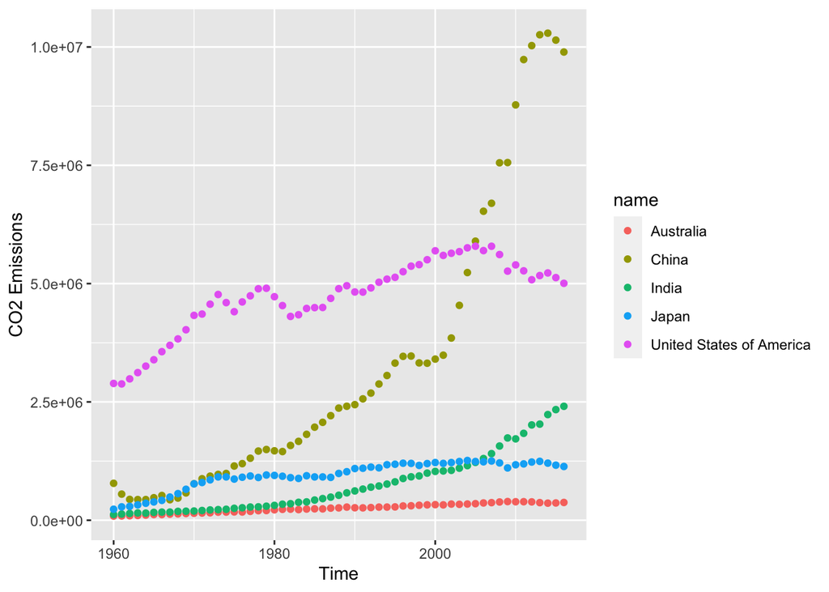

```r
co2_3 <- gapminder %>%
  filter(!is.na(co2)) %>%
  group_by(time, name) %>%
  select(name, time, co2) %>%
  filter(name == "United States of America" | name == "China" | name == "India" | name == "Japan" | name == "Australia")

ggplot(data = co2_3) +
  geom_point(mapping = aes(x = time, y = co2, color = name)) +
  xlab("Time") + ylab("CO2 Emissions")
```

- China have the greatest increase in total CO2 emission. India also have obvious increase trend. Australia have the lowest total emission in these years among these countries. USA have roughly increase trend, but recent decades were increase in decrease speed, even decrease.

#### 3(3).

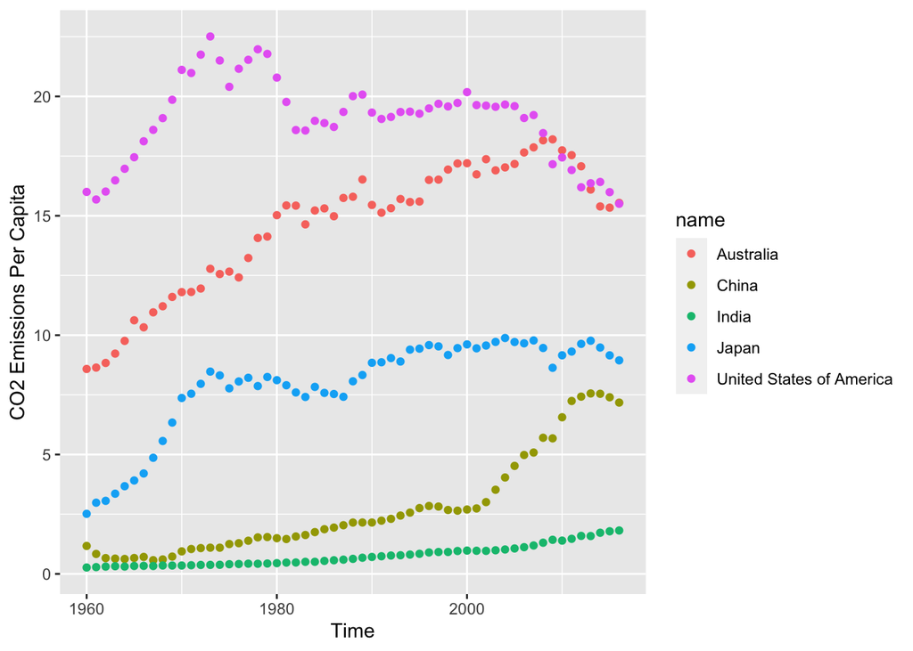

```r
co2PC_3 <- gapminder %>%
  filter(!is.na(co2_PC)) %>%
  group_by(time, name) %>%
  select(name, time, co2_PC) %>%
  filter(name == "United States of America" | name == "China" | name == "India"| name == "Japan" | name == "Australia")

ggplot(data = co2PC_3) +
  geom_point(mapping = aes(x = time, y = co2_PC, color = name)) +
  xlab("Time") + ylab("CO2 Emissions Per Capita")
```

- The USA has the most significant CO2 emissions per capita. And Australia has the second largest emission, Even though Australia did not have substantial CO2 emissions in total. For China, per capita data is much less than the total emission. This figure suggests that the total CO2 emission is totally different when a change to per capita.

#### 3(4).

```r
avgcontinent <- gapminder %>%
  filter(time == 1960 | time == 2016) %>%
  filter(!is.na(co2_PC)) %>%
  filter(!is.na(region)) %>%
  group_by(region, time) %>%
  summarize(co2mission = mean(co2_PC, na.rm = TRUE))
avgcontinent
```

```
## # A tibble: 10 × 3
## # Groups:   region [5]
##    region    time co2mission
##    <chr>    <dbl>      <dbl>
##  1 Africa    1960      0.291
##  2 Africa    2016      1.20
##  3 Americas  1960      7.15
##  4 Americas  2016      4.80
##  5 Asia      1960      1.74
##  6 Asia      2016      6.47
##  7 Europe    1960      5.77
##  8 Europe    2016      6.64
##  9 Oceania   1960      2.73
## 10 Oceania   2016      4.57
```

#### 3(5).

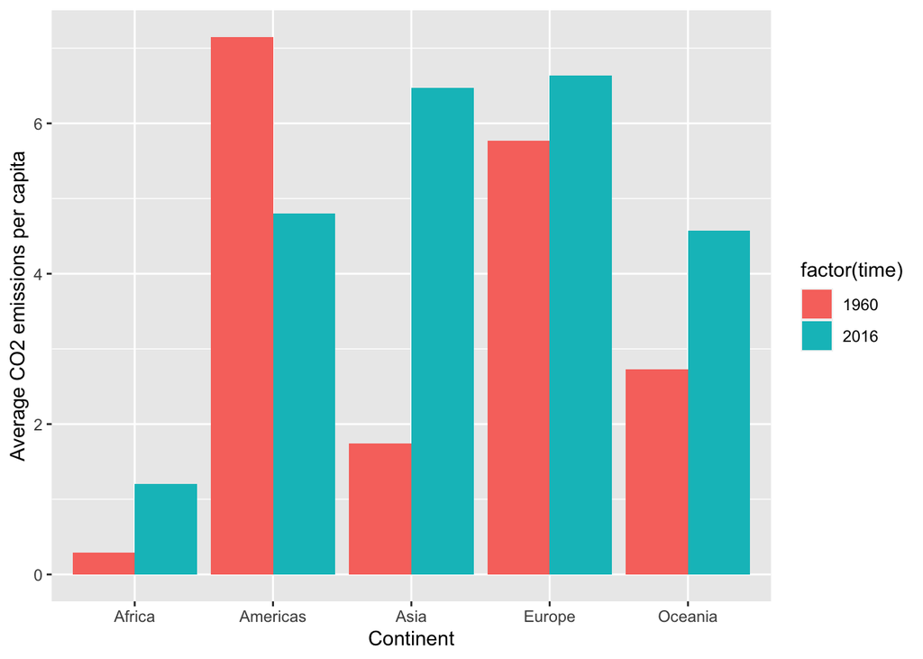

```r
avgcontinent %>%
  filter(time == 1960 | time == 2016) %>%
  ggplot() +
  geom_col(aes(x = region, y = co2mission, fill = factor(time)),
           pos = "dodge") +
  xlab("Continent") + ylab("Average CO2 emissions per capita")
```

#### 3(6).

```r
gapminder %>%
  filter(!is.na(name)) %>%
  filter(time == 2016) %>%
  group_by(region) %>%
  select(name, region, co2_PC) %>%
  arrange(co2_PC) %>%
  filter(rank(co2_PC) <= 3 |rank(desc(co2_PC)) <= 3) %>%
  arrange(region) %>%
  print()
```

```
## # A tibble: 30 × 3
## # Groups:   region [5]
##    name                              region    co2_PC
##    <chr>                             <chr>      <dbl>
##  1 Congo, Democratic Republic of the Africa    0.0256
##  2 Somalia                           Africa    0.0455
##  3 Burundi                           Africa    0.0472
##  4 Seychelles                        Africa    6.39
##  5 Libya                             Africa    7.79
##  6 South Africa                      Africa    8.48
##  7 Haiti                             Americas  0.275
##  8 Nicaragua                         Americas  0.887
##  9 Honduras                          Americas  1.06
## 10 Canada                            Americas 15.1
## # … with 20 more rows
```

### 4.GDP per capita

#### 4(1).

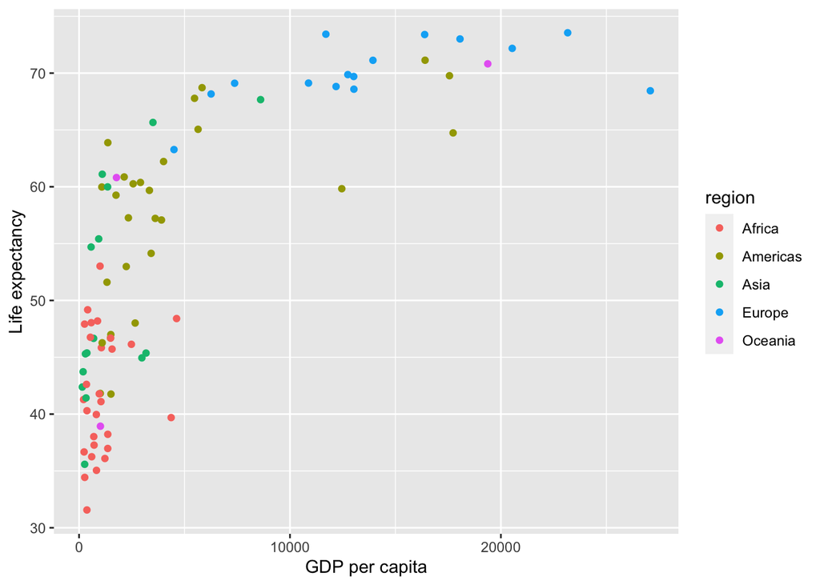

```r
gapminder %>%
  filter(time == 1960) %>%
  filter(!is.na(GDP_PC)) %>%
  filter(!is.na(lifeExpectancy)) %>%
ggplot() +
  geom_point(mapping = aes(x = GDP_PC, y = lifeExpectancy, color = region)) +
  xlab("GDP per capita") + ylab("Life expectancy")
```

- Europe have the greatest GDP per capita and life expectancy in average. Some Americas countries have both high GDP and life expectancy while most countries in Americas only have high life expectancy. Africa and Asia have relative low in life expectancy and GDP per capita.

#### 4(2).

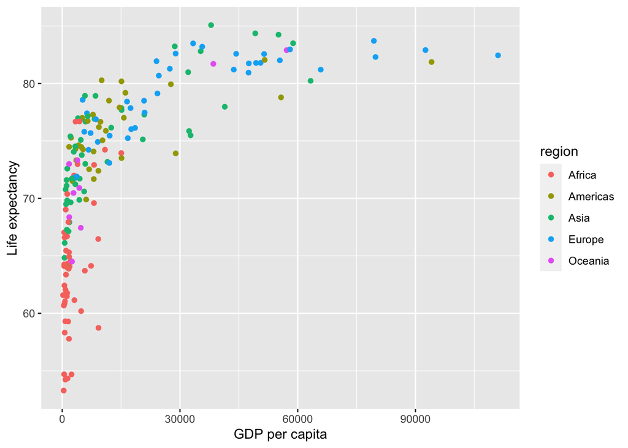

```r
gapminder %>%
  filter(!is.na(region)) %>%
  filter(time == 2019) %>%
  filter(!is.na(GDP_PC)) %>%
  filter(!is.na(lifeExpectancy)) %>%
ggplot() +
  geom_point(mapping = aes(x = GDP_PC, y = lifeExpectancy, color = region)) +  xlab("GDP per capita") + ylab("Life expectancy")
```

#### 4(3).

- As the world develops, more countries are growing and progressing in life expectancy and GDP per capita. Overall, the world’s life expectancy is also rising. An increasing number of Asian countries have higher GDP per capita, but most African countries are not growing in GDP per capita. Over the past 60 years, the life expectancy of all nations has increased, as has the GDP, but hopefully, Africa and some countries in the Americas will see more growth in GDP per capita in the future.

#### 4(4).

```r
gapminder %>%
  filter(!is.na(region)) %>%
  group_by(region, time) %>%
  filter(time == 1960 | time == 2019) %>%
  summarize(avg_life = mean(lifeExpectancy, na.rm = TRUE))
```

```
## # A tibble: 10 × 3
## # Groups:   region [5]
##    region    time avg_life
##    <chr>    <dbl>    <dbl>
##  1 Africa    1960     41.5
##  2 Africa    2019     64.1
##  3 Americas  1960     58.6
##  4 Americas  2019     75.8
##  5 Asia      1960     51.6
##  6 Asia      2019     74.6
##  7 Europe    1960     68.3
##  8 Europe    2019     79.4
##  9 Oceania   1960     56.4
## 10 Oceania   2019     73.5
```

- Yes, the results fit with what do you see on the figures. When compare average life expectancy in 1960 and 2019, every region shown greater increase.

#### 4(5).

```r
gapminder %>%
  filter(time == 1960 | time == 2019) %>%
  filter(!is.na(region)) %>%
  group_by(region, time) %>%
  summarize(avg_life = mean(lifeExpectancy, na.rm = TRUE)) %>%
  mutate(growth = avg_life - lag(avg_life)) %>%
  group_by(region) %>%
  summarize(growth_rate = mean(growth, na.rm = TRUE)) %>%
  arrange(desc(growth_rate))
```

```
## # A tibble: 5 × 2
##   region   growth_rate
##   <chr>          <dbl>
## 1 Asia            23.0
## 2 Africa          22.6
## 3 Americas        17.2
## 4 Oceania         17.1
## 5 Europe          11.1
```

- Asia and Africa have greatest growth rate. While Europe have the lowest growth rate.

#### 4(6).

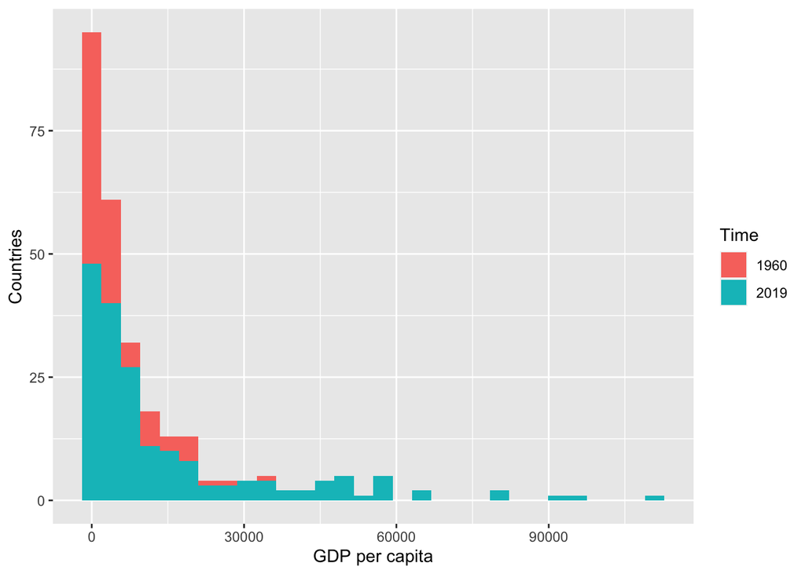

```r
gapminder %>%
  filter(!is.na(region)) %>%
  filter(!is.na(GDP_PC)) %>%
  filter(time == 1960 | time == 2019) %>%
  ggplot(aes(x = GDP_PC, fill = factor(time))) +
  geom_histogram() +
  labs(x = "GDP per capita", y = "Countries", fill = "Time")
```

#### 4(7).

```r
rank_1960 <- gapminder %>%
  filter(time == 1960) %>%
  filter(!is.na(iso2)) %>%
  group_by(time) %>%
  select("iso2", "time", "lifeExpectancy") %>%
  arrange(desc(lifeExpectancy)) %>%
  mutate(rank = rank(desc(lifeExpectancy)))
rank_1960[rank_1960$iso2 == "US", ]
```

```
## # A tibble: 1 × 4
## # Groups:   time [1]
##   iso2   time lifeExpectancy  rank
##   <chr> <dbl>          <dbl> <dbl>
## 1 US     1960           69.8    17
```

```r
rank_2019 <- gapminder %>%
  filter(time == 2019) %>%
  filter(!is.na(iso2)) %>%
  group_by(time) %>%
  select("iso2", "time", "lifeExpectancy") %>%
  arrange(desc(lifeExpectancy)) %>%
  mutate(rank = rank(desc(lifeExpectancy)))
rank_2019[rank_2019$iso2 == "US", ]
```

```
## # A tibble: 1 × 4
## # Groups:   time [1]
##   iso2   time lifeExpectancy  rank
##   <chr> <dbl>          <dbl> <dbl>
## 1 US     2019           78.8    46
```

#### 4(8).

```r
gapminder %>%
  filter(!is.na(region)) %>%
  filter(time == 1960 | time == 2019) %>%
  filter(!is.na(lifeExpectancy)) %>%
  group_by(time) %>%
  mutate(ranks = (rank(desc(lifeExpectancy)) / n_distinct(iso2))) %>%
  filter(iso2 == "US") %>%
  select(iso2, ranks, lifeExpectancy, time)
```

```
## # A tibble: 2 × 4
## # Groups:   time [2]
##   iso2   ranks lifeExpectancy  time
##   <chr>  <dbl>          <dbl> <dbl>
## 1 US    0.0904           69.8  1960
## 2 US    0.235            78.8  2019
```